# Q1 Chemical composition of pottery

You work for a pottery manufacturing company that produces two different types of products A and B. Product A uses raw material from Llanedyrn and Product B uses raw material from Isle Thorns and Ashley Rails. Your company is informed that Llanedyrn will be closing soon for maintenance and your entire production of product A is at risk.

You received a potential new source of raw material from site Caldicot and you analyzed two samples to compare them to your existing samples from the other three sites. As the new data scientist of the company you are asked to look into the data and give your recommendation regarding the suitability of raw material from Caldicot as a replacement for Llanedyrn.

The ask ”look into the data” normally calls for an unsupervised learning exercise, since there is no clear output you are asked to predict. You will investigate the multivariate chemical composition of the raw material from four different sources using Principal Component Analysis.

## 1.1 Data exploration with PCA

```python
import  pandas as pd
import  numpy as np
import  matplotlib.pyplot as plt
import  seaborn as sns
from mpl_toolkits.mplot3d import Axes3D
from sklearn.decomposition import PCA
from sklearn.preprocessing import StandardScaler
from sklearn.preprocessing import MaxAbsScaler
```

### 1. Import and view the data. How many columns do you have? Which columns will you use in your PCA?

```python
Pottery = pd.read_excel('Pottery.xlsx')
```

```python
Pottery.shape
```

```
(26, 7)
```

```python
Pottery
```

|  | Unnamed: 0 | Site | Al | Fe | Mg | Ca | Na |
| --- | --- | --- | --- | --- | --- | --- | --- |
| 0 | 1 | Llanedyrn | 14.4 | 7.00 | 4.30 | 0.15 | 0.51 |
| 1 | 2 | Llanedyrn | 13.8 | 7.08 | 3.43 | 0.12 | 0.17 |
| 2 | 3 | Llanedyrn | 14.6 | 7.09 | 3.88 | 0.13 | 0.20 |
| 3 | 4 | Llanedyrn | 11.5 | 6.37 | 5.64 | 0.16 | 0.14 |
| 4 | 5 | Llanedyrn | 13.8 | 7.06 | 5.34 | 0.20 | 0.20 |
| 5 | 6 | Llanedyrn | 10.9 | 6.26 | 3.47 | 0.17 | 0.22 |
| 6 | 7 | Llanedyrn | 10.1 | 4.26 | 4.26 | 0.20 | 0.18 |
| 7 | 8 | Llanedyrn | 11.6 | 5.78 | 5.91 | 0.18 | 0.16 |
| 8 | 9 | Llanedyrn | 11.1 | 5.49 | 4.52 | 0.29 | 0.30 |
| 9 | 10 | Llanedyrn | 13.4 | 6.92 | 7.23 | 0.28 | 0.20 |
| 10 | 11 | Llanedyrn | 12.4 | 6.13 | 5.69 | 0.22 | 0.54 |
| 11 | 12 | Llanedyrn | 13.1 | 6.64 | 5.51 | 0.31 | 0.24 |
| 12 | 13 | Llanedyrn | 12.7 | 6.69 | 4.45 | 0.20 | 0.22 |
| 13 | 14 | Llanedyrn | 12.5 | 6.44 | 3.94 | 0.22 | 0.23 |
| 14 | 15 | Caldicot | 11.8 | 5.44 | 3.94 | 0.30 | 0.04 |
| 15 | 16 | Caldicot | 11.6 | 5.39 | 3.77 | 0.29 | 0.06 |
| 16 | 17 | IsleThorns | 18.3 | 1.28 | 0.67 | 0.03 | 0.03 |
| 17 | 18 | IsleThorns | 15.8 | 2.39 | 0.63 | 0.01 | 0.04 |
| 18 | 19 | IsleThorns | 18.0 | 1.50 | 0.67 | 0.01 | 0.06 |
| 19 | 20 | IsleThorns | 18.0 | 1.88 | 0.68 | 0.01 | 0.04 |
| 20 | 21 | IsleThorns | 20.8 | 1.51 | 0.72 | 0.07 | 0.10 |
| 21 | 22 | AshleyRails | 17.7 | 1.12 | 0.56 | 0.06 | 0.06 |
| 22 | 23 | AshleyRails | 18.3 | 1.14 | 0.67 | 0.06 | 0.05 |
| 23 | 24 | AshleyRails | 16.7 | 0.92 | 0.53 | 0.01 | 0.05 |
| 24 | 25 | AshleyRails | 14.8 | 2.74 | 0.67 | 0.03 | 0.05 |
| 25 | 26 | AshleyRails | 19.1 | 1.64 | 0.60 | 0.10 | 0.03 |

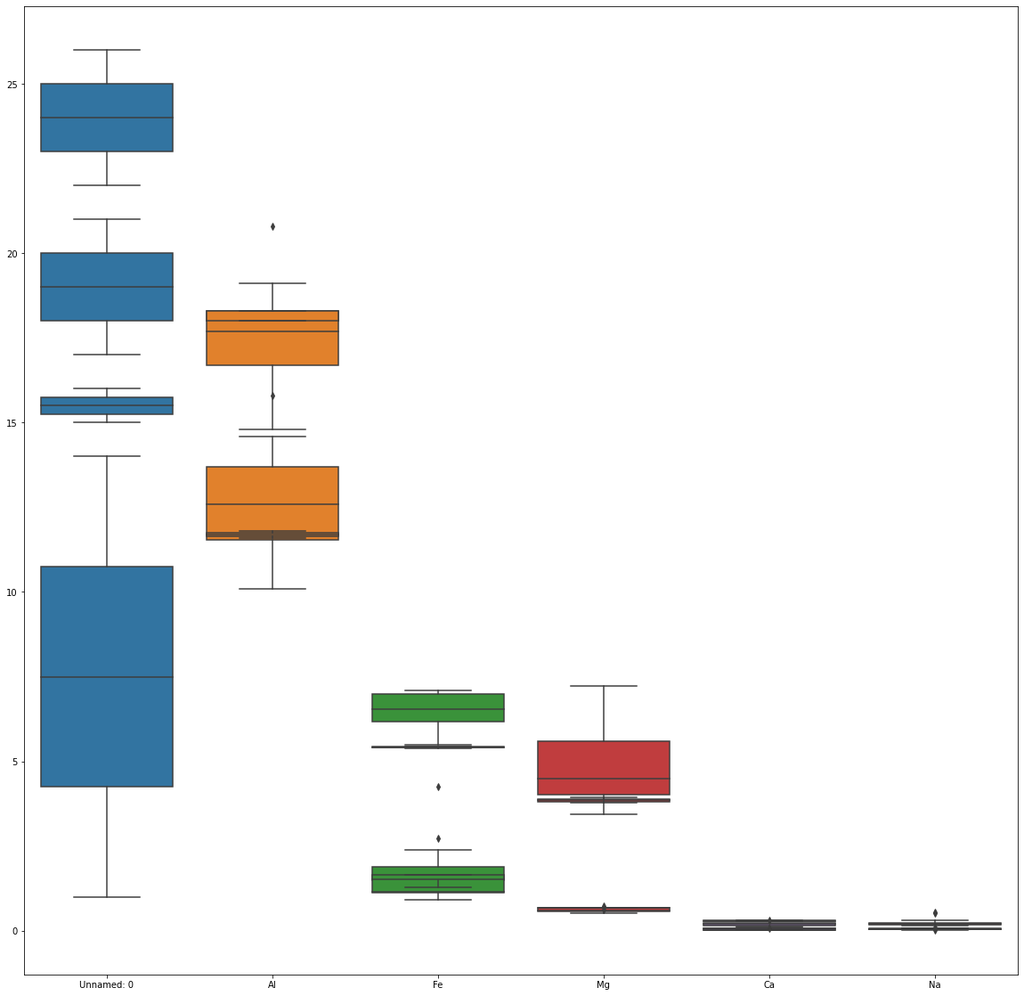

```python
for site in ['Llanedyrn', 'Caldicot', 'IsleThorns', 'AshleyRails']:
    city = Pottery.groupby('Site').get_group(site)
    sns.boxplot(data = city)
```

As it can be seen above there are 7 columns in the table, also found from the '.shape' function.

The only useless one is the 1st column that shows the index value of the sites and samples from the respective sites. Looking at the data from only numerical perspective, the 2nd column of site is also useless however, a way to not include these in furthur processing is to index it as its done below.

### 2. Pre-process the data and perform PCA with 3 PCs.

#### Pre-processing the Data

```python
Pottery.drop(columns = ['Unnamed: 0'], inplace = True)
Pottery.set_index('Site', inplace = True)
Pottery
```

| Site | Al | Fe | Mg | Ca | Na |
| --- | --- | --- | --- | --- | --- |
| Llanedyrn | 14.4 | 7.00 | 4.30 | 0.15 | 0.51 |
| Llanedyrn | 13.8 | 7.08 | 3.43 | 0.12 | 0.17 |
| Llanedyrn | 14.6 | 7.09 | 3.88 | 0.13 | 0.20 |
| Llanedyrn | 11.5 | 6.37 | 5.64 | 0.16 | 0.14 |
| Llanedyrn | 13.8 | 7.06 | 5.34 | 0.20 | 0.20 |
| Llanedyrn | 10.9 | 6.26 | 3.47 | 0.17 | 0.22 |
| Llanedyrn | 10.1 | 4.26 | 4.26 | 0.20 | 0.18 |
| Llanedyrn | 11.6 | 5.78 | 5.91 | 0.18 | 0.16 |
| Llanedyrn | 11.1 | 5.49 | 4.52 | 0.29 | 0.30 |
| Llanedyrn | 13.4 | 6.92 | 7.23 | 0.28 | 0.20 |
| Llanedyrn | 12.4 | 6.13 | 5.69 | 0.22 | 0.54 |
| Llanedyrn | 13.1 | 6.64 | 5.51 | 0.31 | 0.24 |
| Llanedyrn | 12.7 | 6.69 | 4.45 | 0.20 | 0.22 |
| Llanedyrn | 12.5 | 6.44 | 3.94 | 0.22 | 0.23 |
| Caldicot | 11.8 | 5.44 | 3.94 | 0.30 | 0.04 |
| Caldicot | 11.6 | 5.39 | 3.77 | 0.29 | 0.06 |
| IsleThorns | 18.3 | 1.28 | 0.67 | 0.03 | 0.03 |
| IsleThorns | 15.8 | 2.39 | 0.63 | 0.01 | 0.04 |
| IsleThorns | 18.0 | 1.50 | 0.67 | 0.01 | 0.06 |
| IsleThorns | 18.0 | 1.88 | 0.68 | 0.01 | 0.04 |
| IsleThorns | 20.8 | 1.51 | 0.72 | 0.07 | 0.10 |
| AshleyRails | 17.7 | 1.12 | 0.56 | 0.06 | 0.06 |
| AshleyRails | 18.3 | 1.14 | 0.67 | 0.06 | 0.05 |
| AshleyRails | 16.7 | 0.92 | 0.53 | 0.01 | 0.05 |
| AshleyRails | 14.8 | 2.74 | 0.67 | 0.03 | 0.05 |
| AshleyRails | 19.1 | 1.64 | 0.60 | 0.10 | 0.03 |

#### Exploratory Data analysis

- Scatter Plot
- Correlation

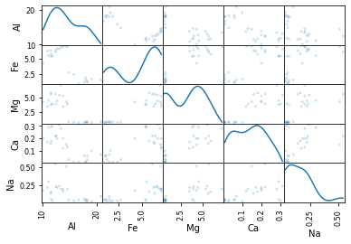

```python
#from pandas.plotting import scatter_matrix
pd.plotting.scatter_matrix(Pottery, alpha=0.2, diagonal = 'kde');
```

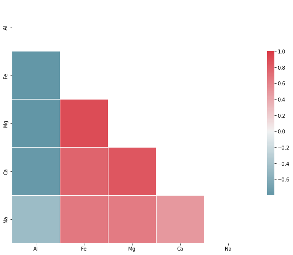

```python
corr = Pottery.corr()

# Generate a mask for the upper triangle
mask = np.zeros_like(corr, dtype=bool)
mask[np.triu_indices_from(mask)] = True

# Set up the matplotlib figure
f, ax = plt.subplots(figsize=(11, 9))

# Generate a custom diverging colormap
cmap = sns.diverging_palette(220, 10, as_cmap=True)

# Draw the heatmap with the mask and correct aspect ratio
sns.heatmap(corr, mask=mask, cmap=cmap, vmax=1, center=0,
            square=True, linewidths=.5, cbar_kws={"shrink": .6})
plt.show()
```

#### Standardize the Data

```python
# scaler = StandardScaler()
# scaler
# Pottery_scaled = scaler.fit_transform(Pottery)
# Pottery_scaled
```

```python
# The above standardizing function can be abriviated into the following function.

Pottery_scaled = StandardScaler().fit_transform(Pottery)
```

```python
Pottery_scaled
```

```
array([[-0.03145568,  1.07166989,  0.54199637,  0.03487194,  2.64999905],
       [-0.23591756,  1.1055258 ,  0.13495926, -0.26735151,  0.08698028],
       [ 0.03669829,  1.10975779,  0.3454957 , -0.16661036,  0.31312899],
       [-1.01968814,  0.80505457,  1.1689271 ,  0.13561308, -0.13916844],
       [-0.23591756,  1.09706182,  1.02856948,  0.53857767,  0.31312899],
       [-1.22415003,  0.75850268,  0.15367361,  0.23635423,  0.4638948 ],
       [-1.49676588, -0.08789516,  0.52328202,  0.53857767,  0.16236318],
       [-0.98561116,  0.5553672 ,  1.29524897,  0.33709538,  0.01159737],
       [-1.15599607,  0.43263951,  0.6449253 ,  1.44524799,  1.06695804],
       [-0.37222549,  1.03781397,  1.91282252,  1.34450685,  0.31312899],
       [-0.71299531,  0.70348682,  1.19232004,  0.74005996,  2.87614776],
       [-0.47445644,  0.91931828,  1.10810547,  1.64673029,  0.61466061],
       [-0.61076436,  0.94047822,  0.61217519,  0.53857767,  0.4638948 ],
       [-0.67891832,  0.83467849,  0.37356722,  0.74005996,  0.53927771],
       [-0.9174572 ,  0.41147957,  0.37356722,  1.54598914, -0.89299749],
       [-0.98561116,  0.39031962,  0.29403123,  1.44524799, -0.74223168],
       [ 1.29754661, -1.34902795, -1.15633091, -1.17402183, -0.9683804 ],
       [ 0.44562207, -0.87927715, -1.17504526, -1.37550412, -0.89299749],
       [ 1.19531566, -1.25592419, -1.15633091, -1.37550412, -0.74223168],
       [ 1.19531566, -1.0951086 , -1.15165232, -1.37550412, -0.89299749],
       [ 2.14947114, -1.2516922 , -1.13293797, -0.77105724, -0.44070006],
       [ 1.09308472, -1.41673978, -1.20779537, -0.87179839, -0.74223168],
       [ 1.29754661, -1.4082758 , -1.15633091, -0.87179839, -0.81761459],
       [ 0.7523149 , -1.50137956, -1.22183113, -1.37550412, -0.81761459],
       [ 0.10485225, -0.73115752, -1.15633091, -1.17402183, -0.81761459],
       [ 1.57016246, -1.19667634, -1.18908102, -0.4688338 , -0.9683804 ]])
```

```python
# Confirming the mean of the scaled columns after the function.

Pottery_scaled.mean(axis = 0)
```

```
array([5.12410627e-17, 1.70803542e-17, 4.27008856e-17, 3.84307970e-17,
       5.97812398e-17])
```

```python
# Confirming the std of the scaled columns after the function.

Pottery_scaled.std(axis = 0)
```

```
array([1., 1., 1., 1., 1.])
```

```python
Pottery_scaled.shape
```

```
(26, 5)
```

#### Performing PCA with 3 PCs

```python
pca = PCA(n_components = 3, svd_solver = 'full')
```

```python
Pottery_scores = pca.fit_transform(Pottery_scaled)

# Pottery scores
```

```python
Pottery_scores.shape
```

```
(26, 3)
```

#### Extracting the scores in the form of Pandas Dataframe (26 rows x 3 columns (scores))

Scores are meant to reproduce the index/rows's data in the form of PCA.

```python
Pottery_scores_pd = pd.DataFrame(data = Pottery_scores,
                                        columns = ['PC1', 'PC2', 'PC3'],
                                        index = Pottery.index)
```

```python
Pottery_scores_pd
```

| Site | PC1 | PC2 | PC3 |
| --- | --- | --- | --- |
| Llanedyrn | -1.778026 | 2.289445 | -0.075289 |
| Llanedyrn | -0.611193 | 0.122065 | -0.499044 |
| Llanedyrn | -0.722428 | 0.370209 | -0.207550 |
| Llanedyrn | -1.417696 | -0.555600 | -0.557590 |
| Llanedyrn | -1.486801 | -0.004081 | 0.195248 |
| Llanedyrn | -1.259044 | -0.092347 | -0.783259 |
| Llanedyrn | -1.180703 | -0.607921 | -0.575010 |
| Llanedyrn | -1.490385 | -0.498745 | -0.336582 |
| Llanedyrn | -2.076010 | 0.000500 | 0.220714 |
| Llanedyrn | -2.311320 | -0.376341 | 0.800851 |
| Llanedyrn | -2.621615 | 1.952241 | 0.094513 |
| Llanedyrn | -2.155016 | -0.220571 | 0.828020 |
| Llanedyrn | -1.431624 | 0.007079 | -0.106344 |
| Llanedyrn | -1.413437 | -0.013782 | -0.037041 |
| Caldicot | -1.153767 | -1.634243 | 0.411643 |
| Caldicot | -1.145386 | -1.490205 | 0.286453 |
| IsleThorns | 2.668073 | 0.029649 | 0.126326 |
| IsleThorns | 2.135919 | -0.119176 | -0.680174 |
| IsleThorns | 2.585526 | 0.262264 | -0.096612 |
| IsleThorns | 2.561672 | 0.138060 | -0.121480 |
| IsleThorns | 2.615076 | 0.654624 | 0.983277 |
| AshleyRails | 2.415728 | 0.048399 | 0.193736 |
| AshleyRails | 2.505373 | 0.053793 | 0.342508 |
| AshleyRails | 2.565084 | 0.032170 | -0.376411 |
| AshleyRails | 1.786069 | -0.239541 | -0.799486 |
| AshleyRails | 2.415928 | -0.107947 | 0.768582 |

#### Extracting the loadings in the form of Pandas DataFrame, based on the Columns, new dimension on the PCs

Loadings are meant to reproduce the column's data in the form of PCA.

```python
Pottery_loadings_pd = pd.DataFrame(data = pca.components_.T
                           ,columns = ['PC1', 'PC2', 'PC3']
                           ,index = Pottery.columns)
```

```python
Pottery_loadings_pd
```

|  | PC1 | PC2 | PC3 |
| --- | --- | --- | --- |
| Al | 0.445434 | 0.356524 | 0.694985 |
| Fe | -0.478132 | 0.041175 | -0.157338 |
| Mg | -0.486541 | -0.049607 | 0.158560 |
| Ca | -0.449054 | -0.344146 | 0.683443 |
| Na | -0.366888 | 0.866197 | 0.002043 |

### 3. Plot the cumulative explained variance graph. What percent of the variance do the first 2 and 3 components describe?

#### Some PCA diagnostics that show and explain the Variance

```python
pca.explained_variance_
```

```
array([4.03290887, 0.63316224, 0.25395987])
```

```python
pca.explained_variance_ratio_*100
```

```
array([77.55593977, 12.17619687,  4.88384364])
```

```python
pca5 = PCA(n_components = 5, svd_solver = 'full')
```

```python
pca5.fit(Pottery_scaled)
```

```
PCA(n_components=5, svd_solver='full')
```

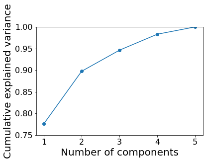

```python
plt.plot(range(1,pca5.n_components+1), np.cumsum(pca5.explained_variance_ratio_),'-o')
plt.xlabel('Number of components', fontsize=20)
plt.ylabel('Cumulative explained variance', fontsize=20);
plt.tick_params(labelsize=16)
plt.ylim(0.75,1)
plt.show()
```

With the first 2 Principle Components - 90% of the variance is explained. i.e. If we compress the data from the 5 columns into just 2 PCs, then 90% of the data will be retained and extracted into these 2 components.

With the first 3 Priciple Componets - 95% of the variane is explained. i.e. If we choose 3 PCs instead of 2 then 95% of the data from 5 columns is retained and extracted into these 3 columns.

### 4. Plot the scores-loadings graph for PC1-PC2. Visualize the different sites with a different colour or symbol.

```python
def myplot(scores,loadings,loading_labels=None,score_labels=None):
    # adjusting the scores to fit in (-1,1)
    xt = scores[:,0]
    yt = scores[:,1]
    n = loadings.shape[0]
    scalext = 1.0/(xt.max() - xt.min())
    scaleyt = 1.0/(yt.max() - yt.min())
    xt_scaled = xt * scalext
    yt_scaled = yt * scaleyt
    # adjusting the loadings to fit in (-1,1)
    p = loadings
    p_scaled = MaxAbsScaler().fit_transform(p)

    #plt.scatter(xs * scalex,ys * scaley, s=10)
    for (x,y), label in zip(np.vstack((xt_scaled, yt_scaled)).T,score_labels):
        plt.text(x, y, label, ha='center', size=11)

    for i in range(n):
        plt.arrow(0, 0, p_scaled[i,0], p_scaled[i,1], color = 'r',alpha = 0.5)
        if loading_labels is None:
            plt.text(p_scaled[i,0], p_scaled[i,1], "Var"+str(i+1), color = 'g', ha = 'center', va = 'center')
        else:
            plt.text(p_scaled[i,0], p_scaled[i,1], loading_labels[i], color = 'r', ha = 'center', va = 'center', size=16)
    plt.xlim(-1,1)
    plt.ylim(-0.5,1)
    plt.xlabel("PC{}".format(1), fontsize=20);
    plt.ylabel("PC{}".format(2), fontsize=20);
    plt.tick_params(labelsize=16)
    plt.grid()
```

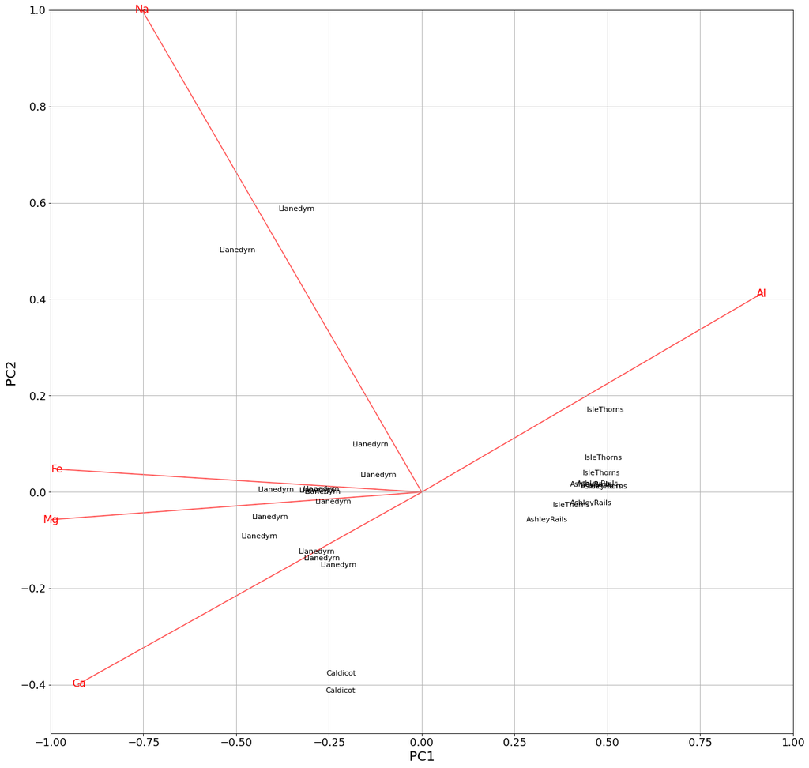

```python
plt.rcParams["figure.figsize"] = [20,20]
myplot(Pottery_scores[:,:2],Pottery_loadings_pd.iloc[:,:2],loading_labels=Pottery_loadings_pd.index,score_labels=Pottery_scores_pd.index)
plt.show()
```

```python
def my3Dplot(score,coeff,loading_labels=None,score_labels=None):
    fig = plt.figure()
    ax = fig.add_subplot(111, projection='3d')

    xs = score[:,0]
    ys = score[:,1]
    zs = score[:,2]
    n = coeff.shape[0]
    scalex = 1.0/(xs.max() - xs.min())
    scaley = 1.0/(ys.max() - ys.min())
    scalez = 1.0/(zs.max() - zs.min())
    xf = xs * scalex
    yf = ys * scaley
    zf = zs * scalez
    #plt.scatter(xs * scalex,ys * scaley, s=10)
    for (x,y,z), label in zip(np.vstack((xf, yf, zf)).T,score_labels):
        ax.text(x, y, z, label, ha='center', size=11)
    plt.xlim(-1,1)
    plt.ylim(-1,1)
    ax.set_zlim(-1,1)
    plt.xlabel("PC{}".format(1), fontsize=20);
    plt.ylabel("PC{}".format(2), fontsize=20);
    ax.set_zlabel("PC{}".format(3), fontsize=20);
    plt.tick_params(labelsize=16)
    plt.grid()
```

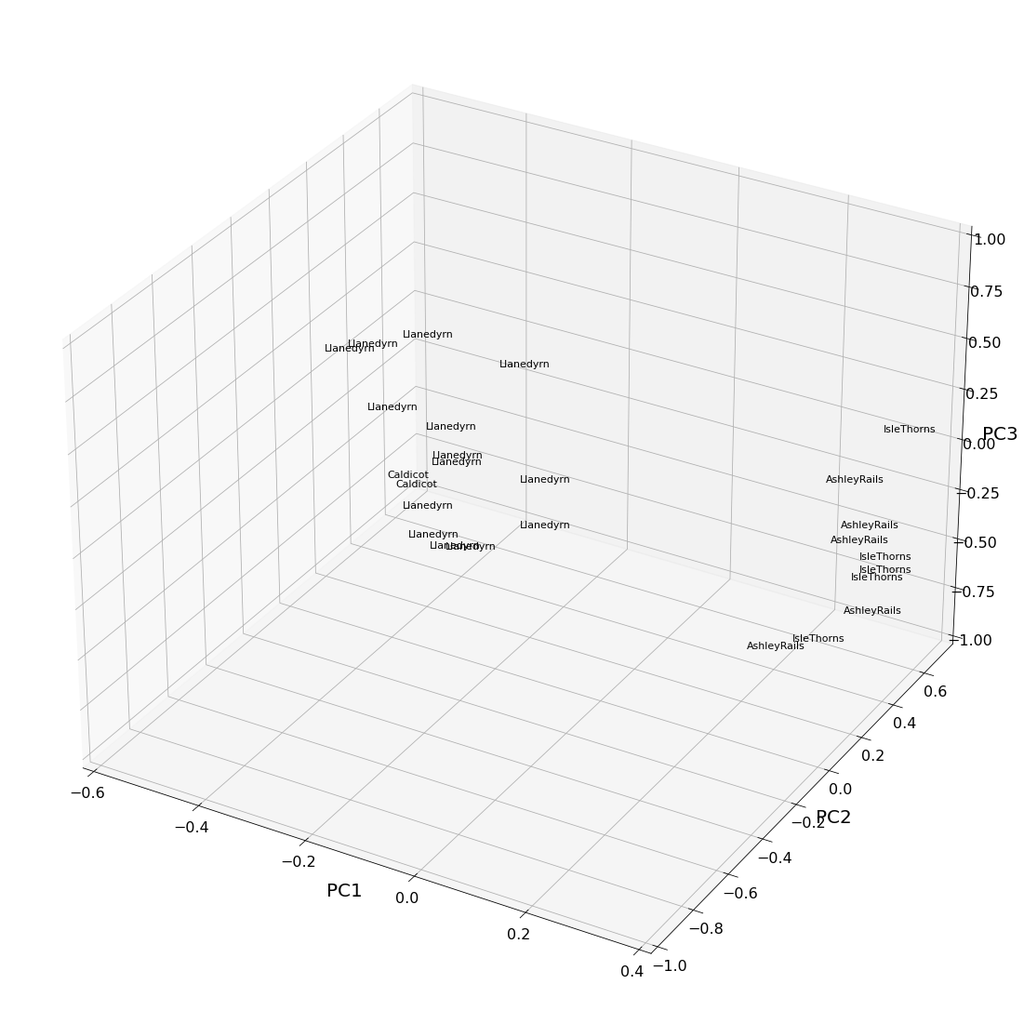

```python
plt.rcParams["figure.figsize"] = [20,20]

my3Dplot(Pottery_scores,np.transpose(pca.components_),loading_labels=Pottery_loadings_pd.index,score_labels=Pottery_scores_pd.index)
plt.xlim(-0.6,0.4)
plt.ylim(-1,0.75)
plt.show()
```

### 5. How does the map of scores-loadings explains the reason that your company uses the raw material from Isle Thorns and Ashley Rails to manufacture Product B?

Assuming Product B, has a high concentration in Al and correspondingly low concentration in the other elements.

This phenonmenon can be obeserved from the map above, such that the Al vector is inversely proportional / negatively correlated to the other elemental vectors. i.e. As the concentration of Al increases, the concentration of the other elements such as Ca, Mg, Fe decreases rapidly, Na concentration also decreases but not as fast as the others.

Now observing the 2 major clusters of data, one is around the center, (0,0), and the other is towards the right hand side (towards Al).

The middle cluster contains names of only 'Llanedyrn' and its raw material's respective concentrations in all the elements. There are a variety of 'Llanedyrn' samples with different concentrations.

The right hand cluster contains names of both, 'Isle Thorns' & 'Ashley Rails'. Raw materials from both locations have high concentration in Al and correspondingly low concentration in other elements, thus this indicates that Product B is made from raw material from these 2 locations.

### 6. Is the raw material from Caldicot a good replacement for Llanedyrn? Yes or no and why?

No, the raw material from Caldicot is not a good replacement for Llanedyrn.

This is because from the map, raw material from Caldicot, appear to be outliers as compared to the other plots. They have somewhat similar properties as the ones in Llanedyrn that have higher Ca concentrations however the other raw material from the Llanedyrn provides samples with diversified concentrations in other elements such as Fe, Mg and Na. as it can be seen by the 2 samples high on the Na vector.

Therefore this also indicates that the number of samples provided from Caldicot is extremly less (only 2) and thus not giving us a very clear idea of whether it would serve as a replacment for samples from Llanedyrn. The provided samples only have strong Ca concentrations, if more samples were taken, there could be a possibility of samples with higher concentration in other elements aswell, thus would provide a better picture for a replacement.

Thus due to lack of enough data from Caldicot and due to high concentration in Ca only in the 2 samples provided, raw material from Caldicot does not serve as a good replacement for Llanedyrn.

### 7. What are the biggest differences in the two big clusters? How are the two samples from the candidate Caldicot different than the Llanedyrn samples?

As discussed in the previous 2 sessions, the main difference between the 2 clusters, is that the middle cluster only has raw material samples from Llanedyrn and the right hand cluster has raw materials from Isle Thorns and Ashley Rails. This indicates that Product B has high Al concentration and Product A has low Al concentration compared to the rest. And vice versa for the other elements.

The 2 samples from Caldicot vary from the Llanedyrn ones by thier concentration of Ca, most Llanedyrn samples have a balance of concentrations of most elements whilest these 2 from Caldicot, have more concentration of Ca, similar to the Llanedyrn samples with high Ca concentration.

But as previously mentioned, just 2 samples from Caldicot don't clearly indicate whether it would serve as a good replacement for Llanedyrn.

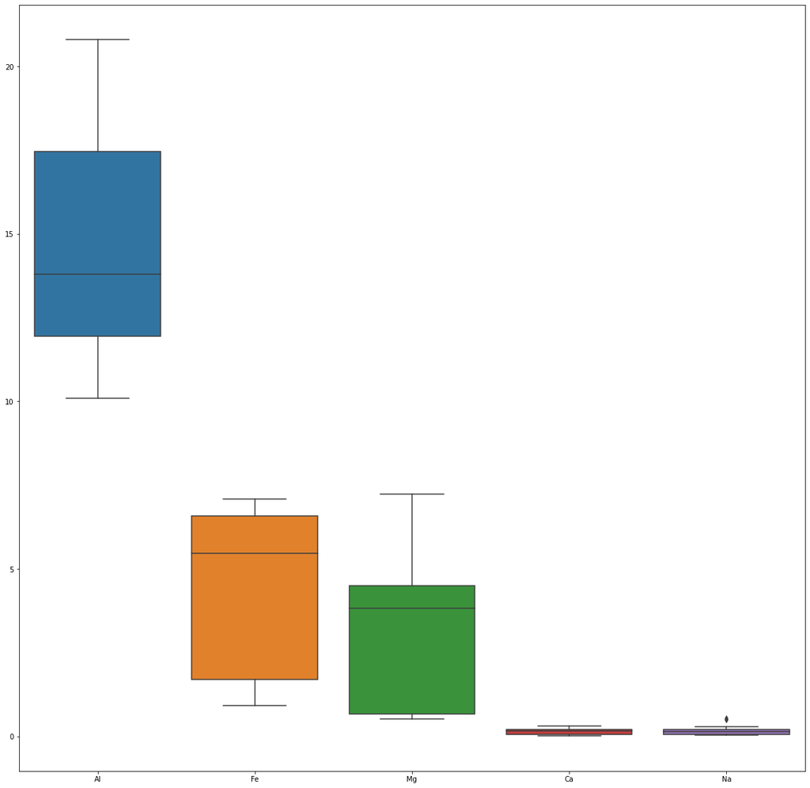

```python
sns.boxplot(data = Pottery)
```